# Practical Machine Learning - Course Assignment

Rick M

2/21/2020

## Executive Summary

The aim of the project is to predict how well an exercise (in our project specifically is barbell lifts) is done according to a set of variables that have been derived using sensors applied on the body.

The training data for this project are available here: https://d396qusza40orc.cloudfront.net/predmachlearn/pml-training.csv

The test data are available here: https://d396qusza40orc.cloudfront.net/predmachlearn/pml-testing.csv

The objective is to correctly predict the variable classe of the Test set. This variable indicates how well the exercise is performed. The valua A indicates that the exercise was well performed while the other letters (from B to E) respectively indicate that common mistakes has been done during the execution of the weightlifting.

First the datasets are loaded and only useful variables are considered. Then two different machine learning algorithms are applied to a subset of the training set and then tested to estimate the accuracy. Finally, the best model found is determined and is applied to the test set to predict the type of performance in doing the weightlifting of 20 instances.

## Data Preparation

First, load the packages that are needed to process and read the data for the training data and perform cleaning tasks.

```r
library(caret)
library(randomForest)
```

```r
library(rpart)
library(curl)
library(lattice)
library(ggplot2)
library(rattle)
library(e1071)
URL<- "https://d396qusza40orc.cloudfront.net/predmachlearn/pml-training.csv"
train = read.csv(file=URL, na.strings=c("NA","#DIV/0!", ""))
train <- subset(train, select=-c(1:6))
train2<-train[,colSums(is.na(train)) == 0]
classe <- train2$classe
train2 <- train2[,sapply(train2,is.numeric)]
train2$classe <- classe; rm(classe)
dim(train2)
```

```
## [1] 19622    54
```

```r
URL2<- "https://d396qusza40orc.cloudfront.net/predmachlearn/pml-testing.csv"
test = read.csv(file=URL2, na.strings=c("NA","#DIV/0!", ""))
test <- subset(test, select=-c(1:6))
test2 <-test[,colSums(is.na(test)) == 0]
test2 <- test2[,sapply(test2,is.numeric)]
dim(test2)
```

```
## [1] 20 54
```

Then Identify set column name differences as it will be important in the assesment stage (predcition with test set)

```r
trainCol <- names(train2)
testCol <- names(test2)
setdiff(trainCol, testCol)
```

```
## [1] "classe"
```

```r
setdiff(testCol, trainCol)
```

```
## [1] "problem_id"
```

## Cross-Validation

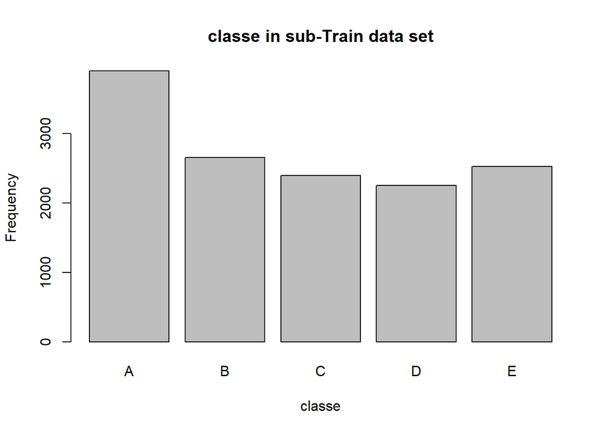

```r
set.seed(221)
samples <- createDataPartition(y=train2$classe, p=0.7, list=FALSE)
sTrain <- train2[samples, ]
sTest <- train2[-samples, ]
plot(sTrain$classe,  main="classe in sub-Train data set", xlab="classe", ylab="Frequency")
```

## Modeling

### First Model: Decision tree model

```r
set.seed(221)
modelTree <- rpart(classe ~ ., data=sTrain, method="class")
predicTree <- predict(modelTree, sTest, type = "class")
```

[figure not shown]

```r
fancyRpartPlot(modelTree,cex=0.4)
```

Next, test the results on the sub-testing data set for this first model:

```r
confusionMatrix(predicTree, sTest$classe)
```

```
## Confusion Matrix and Statistics
##
##           Reference
## Prediction    A    B    C    D    E
##          A 1508  256   47  102   52
##          B   43  620   30   24   25
##          C   11   68  862  144   66
##          D   98  149   59  595  137
##          E   14   46   28   99  802
##
## Overall Statistics
##
##                Accuracy : 0.7455
##                  95% CI : (0.7341, 0.7565)
##     No Information Rate : 0.2845
##     P-Value [Acc > NIR] : < 2.2e-16
##
##                   Kappa : 0.6765
##
##  Mcnemar's Test P-Value : < 2.2e-16
##
## Statistics by Class:
##
##                      Class: A Class: B Class: C Class: D Class: E
## Sensitivity            0.9008   0.5443   0.8402   0.6172   0.7412
## Specificity            0.8915   0.9743   0.9405   0.9100   0.9611
## Pos Pred Value         0.7674   0.8356   0.7489   0.5732   0.8109
## Neg Pred Value         0.9577   0.8991   0.9654   0.9239   0.9428
## Prevalence             0.2845   0.1935   0.1743   0.1638   0.1839
## Detection Rate         0.2562   0.1054   0.1465   0.1011   0.1363
## Detection Prevalence   0.3339   0.1261   0.1956   0.1764   0.1681
## Balanced Accuracy      0.8962   0.7593   0.8903   0.7636   0.8511
```

### Second Model: Random Forest model

```r
set.seed(221)
modelForest <- randomForest(classe ~. , data=sTrain, method="class")
predicForest <- predict(modelForest, sTest, type = "class")
```

Next, test the results on the sub-testing data set for the second model

```r
confusionMatrix(predicForest, sTest$classe)
```

```
## Confusion Matrix and Statistics
##
##           Reference
## Prediction    A    B    C    D    E
##          A 1674    0    0    0    0
##          B    0 1139    2    0    0
##          C    0    0 1024   10    0
##          D    0    0    0  954    1
##          E    0    0    0    0 1081
##
## Overall Statistics
##
##                Accuracy : 0.9978
##                  95% CI : (0.9962, 0.9988)
##     No Information Rate : 0.2845
##     P-Value [Acc > NIR] : < 2.2e-16
##
##                   Kappa : 0.9972
##
##  Mcnemar's Test P-Value : NA
##
## Statistics by Class:
##
##                      Class: A Class: B Class: C Class: D Class: E
## Sensitivity            1.0000   1.0000   0.9981   0.9896   0.9991
## Specificity            1.0000   0.9996   0.9979   0.9998   1.0000
## Pos Pred Value         1.0000   0.9982   0.9903   0.9990   1.0000
## Neg Pred Value         1.0000   1.0000   0.9996   0.9980   0.9998
## Prevalence             0.2845   0.1935   0.1743   0.1638   0.1839
## Detection Rate         0.2845   0.1935   0.1740   0.1621   0.1837
## Detection Prevalence   0.2845   0.1939   0.1757   0.1623   0.1837
## Balanced Accuracy      1.0000   0.9998   0.9980   0.9947   0.9995
```

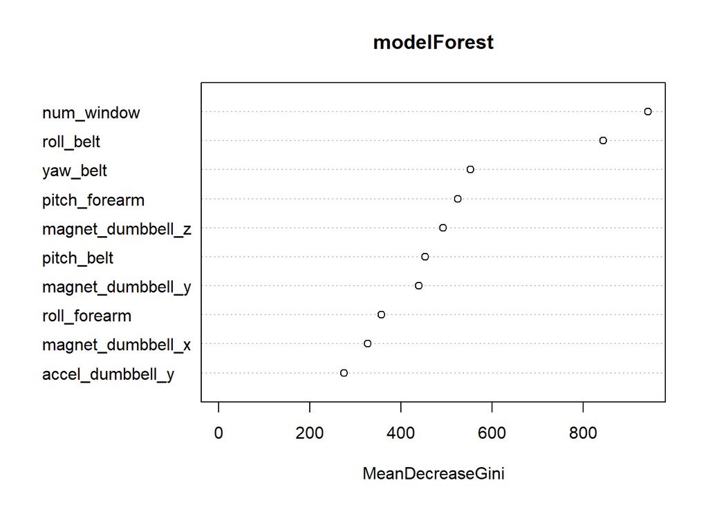

```r
VarImport <- varImp(modelForest)
varImpPlot(modelForest,n.var = 10)
```

## Model Selection

Based in the results, the Random Forest model due to it being a better predictor to the classe variable. Tha Accuracy in Random Forest Model was 0.9978 versus 0.7455 in the Decision Tree Model.

## Submission (Prediction)

Finally, predict 20 values in the testing data set using the Random Forest Model to predict ‘Class’ for each ‘problem_id’

```r
predictF <-predict(modelForest, type="class", newdata = test2[,-which(names(test) %in% "problem_id")])
t(data.frame(problem_id = test2$problem_id, prediction = predictF))
```

```
##            1    2    3    4    5    6    7    8    9    10   11   12   13
## problem_id " 1" " 2" " 3" " 4" " 5" " 6" " 7" " 8" " 9" "10" "11" "12" "13"
## prediction "B"  "A"  "B"  "A"  "A"  "E"  "D"  "B"  "A"  "A"  "B"  "C"  "B"
##            14   15   16   17   18   19   20
## problem_id "14" "15" "16" "17" "18" "19" "20"
## prediction "A"  "E"  "E"  "A"  "B"  "B"  "B"
```